# Airline Data Challenge Capital One

Candidate Name : Sudarshan Ananthakrishnan

# Airline Data Challenge Problem Statement

An airline company is looking to enter the United States domestic market.Specifically,the company has decided to start with 5 round trip routes between medium and large US airports. An example of a round trip route is the combination of JFK to ORD and ORD to JFK. The airline company has to acquire 5 new airplanes (one per round trip route) and the upfront cost for each airplane is $90 million. Identifying the 5 best routes based on factors like occupancy rates, number of flights operating etc is the goal of the project.

# Installing packages

```r
# install.packages("tidyverse")
library(tidyverse)

#install.packages('lubridate')
library(lubridate)

# install.packages('Hmisc')
library(Hmisc)

#install.packages('corrplot')
library(corrplot)

#install.packages('DT')
library(DT)

#install.packages('gt')
library(gt)
```

# Importing Datasets

```r
airport_codes  <- read.csv("C:\\Users\\sudar\\Desktop\\Capital One Airline Data challenge\\data\\airport_codes.csv")

flights <- read.csv("C:\\Users\\sudar\\Desktop\\Capital One Airline Data challenge\\data\\flights.csv")

tickets <-  read.csv("C:\\Users\\sudar\\Desktop\\Capital One Airline Data challenge\\data\\tickets.csv")
```

# Data Exploration of Datasets

```r
summary(airport_codes)
```

```
##      TYPE               NAME            ELEVATION_FT    CONTINENT
##  Length:55369       Length:55369       Min.   :-1266   Length:55369
##  Class :character   Class :character   1st Qu.:  205   Class :character
##  Mode  :character   Mode  :character   Median :  720   Mode  :character
##                                        Mean   : 1245
##                                        3rd Qu.: 1500
##                                        Max.   :22000
##                                        NA's   :7015
##  ISO_COUNTRY        MUNICIPALITY        IATA_CODE         COORDINATES
##  Length:55369       Length:55369       Length:55369       Length:55369
##  Class :character   Class :character   Class :character   Class :character
##  Mode  :character   Mode  :character   Mode  :character   Mode  :character
##
##
##
##
```

```r
# no changes required for the data types of columns in airport_codes

#filtering this data set to include only medium size airports and large size airports in the US

# Checking for any misspelled values of TYPES and ISO_Country that will be used in our filtering

airport_codes %>% group_by(TYPE) %>% summarise(count=n())
```

```
## # A tibble: 7 × 2
##   TYPE           count
##   <chr>          <int>
## 1 balloonport       23
## 2 closed          3680
## 3 heliport       11384
## 4 large_airport    614
## 5 medium_airport  4532
## 6 seaplane_base   1016
## 7 small_airport  34120
```

```r
airport_codes %>% group_by(ISO_COUNTRY) %>% summarise(count=n())
```

```
## # A tibble: 243 × 2
##    ISO_COUNTRY count
##    <chr>       <int>
##  1 ""            247
##  2 "AD"            2
##  3 "AE"           51
##  4 "AF"           62
##  5 "AG"            3
##  6 "AI"            1
##  7 "AL"           12
##  8 "AM"           13
##  9 "AO"          104
## 10 "AQ"           27
## # … with 233 more rows
```

```r
# creating the subset
airport_codes_US <- airport_codes %>%
                    filter((TYPE == 'medium_airport' | TYPE == 'large_airport') & ISO_COUNTRY == 'US' & IATA_CODE != '') %>%
                    select(IATA_CODE,NAME,TYPE)


airport_codes_US %>% group_by(TYPE) %>% summarise(count=n())
```

```
## # A tibble: 2 × 2
##   TYPE           count
##   <chr>          <int>
## 1 large_airport    170
## 2 medium_airport   651
```

```r
summary(flights)
```

```
##    FL_DATE           OP_CARRIER          TAIL_NUM         OP_CARRIER_FL_NUM
##  Length:1915886     Length:1915886     Length:1915886     Length:1915886
##  Class :character   Class :character   Class :character   Class :character
##  Mode  :character   Mode  :character   Mode  :character   Mode  :character
##
##
##
##
##  ORIGIN_AIRPORT_ID    ORIGIN          ORIGIN_CITY_NAME   DEST_AIRPORT_ID
##  Min.   :10135     Length:1915886     Length:1915886     Min.   :10135
##  1st Qu.:11292     Class :character   Class :character   1st Qu.:11292
##  Median :12889     Mode  :character   Mode  :character   Median :12889
##  Mean   :12688                                           Mean   :12689
##  3rd Qu.:14057                                           3rd Qu.:14057
##  Max.   :16218                                           Max.   :16218
##
##  DESTINATION        DEST_CITY_NAME       DEP_DELAY        ARR_DELAY
##  Length:1915886     Length:1915886     Min.   : -63.0   Min.   : -94.00
##  Class :character   Class :character   1st Qu.:  -6.0   1st Qu.: -15.00
##  Mode  :character   Mode  :character   Median :  -2.0   Median :  -6.00
##                                        Mean   :  10.8   Mean   :   5.65
##                                        3rd Qu.:   7.0   3rd Qu.:   8.00
##                                        Max.   :2941.0   Max.   :2923.00
##                                        NA's   :50351    NA's   :55991
##    CANCELLED         AIR_TIME           DISTANCE         OCCUPANCY_RATE
##  Min.   :0.00000   Length:1915886     Length:1915886     Min.   :0.3000
##  1st Qu.:0.00000   Class :character   Class :character   1st Qu.:0.4800
##  Median :0.00000   Mode  :character   Mode  :character   Median :0.6500
##  Mean   :0.02694                                         Mean   :0.6502
##  3rd Qu.:0.00000                                         3rd Qu.:0.8247
##  Max.   :1.00000                                         Max.   :1.0000
##                                                          NA's   :310
```

```r
#changing the datatypes pf these columns

flights$FL_DATE <- ymd(flights$FL_DATE)
flights$AIR_TIME <- as.numeric(flights$AIR_TIME)
flights$DISTANCE <- as.numeric(flights$DISTANCE)
# FL_date changed from character to date.
# Air_time and Distance changed from character to numeric. Also, Airtime has too many missing values or NA's i.e. 58461. We will be excluding this column for our analysis.


summary(flights)
```

```
##     FL_DATE            OP_CARRIER          TAIL_NUM         OP_CARRIER_FL_NUM
##  Min.   :2019-01-01   Length:1915886     Length:1915886     Length:1915886
##  1st Qu.:2019-01-24   Class :character   Class :character   Class :character
##  Median :2019-02-16   Mode  :character   Mode  :character   Mode  :character
##  Mean   :2019-02-15
##  3rd Qu.:2019-03-10
##  Max.   :2019-03-31
##  NA's   :5050
##  ORIGIN_AIRPORT_ID    ORIGIN          ORIGIN_CITY_NAME   DEST_AIRPORT_ID
##  Min.   :10135     Length:1915886     Length:1915886     Min.   :10135
##  1st Qu.:11292     Class :character   Class :character   1st Qu.:11292
##  Median :12889     Mode  :character   Mode  :character   Median :12889
##  Mean   :12688                                           Mean   :12689
##  3rd Qu.:14057                                           3rd Qu.:14057
##  Max.   :16218                                           Max.   :16218
##
##  DESTINATION        DEST_CITY_NAME       DEP_DELAY        ARR_DELAY
##  Length:1915886     Length:1915886     Min.   : -63.0   Min.   : -94.00
##  Class :character   Class :character   1st Qu.:  -6.0   1st Qu.: -15.00
##  Mode  :character   Mode  :character   Median :  -2.0   Median :  -6.00
##                                        Mean   :  10.8   Mean   :   5.65
##                                        3rd Qu.:   7.0   3rd Qu.:   8.00
##                                        Max.   :2941.0   Max.   :2923.00
##                                        NA's   :50351    NA's   :55991
##    CANCELLED          AIR_TIME         DISTANCE       OCCUPANCY_RATE
##  Min.   :0.00000   Min.   :-121.0   Min.   :-1947.0   Min.   :0.3000
##  1st Qu.:0.00000   1st Qu.:  59.0   1st Qu.:  342.0   1st Qu.:0.4800
##  Median :0.00000   Median :  91.0   Median :  606.0   Median :0.6500
##  Mean   :0.02694   Mean   : 109.4   Mean   :  768.3   Mean   :0.6502
##  3rd Qu.:0.00000   3rd Qu.: 139.0   3rd Qu.: 1010.0   3rd Qu.:0.8247
##  Max.   :1.00000   Max.   :2222.0   Max.   : 9898.0   Max.   :1.0000
##                    NA's   :58461    NA's   :2740      NA's   :310
```

```r
# Filtering the flights data to have only have information about flights to and from medium and large US airports

flights_US <- flights %>%
              filter(ORIGIN %in% (airport_codes_US$IATA_CODE) & DESTINATION %in% (airport_codes_US$IATA_CODE))
```

```r
summary(tickets)
```

```
##     ITIN_ID               YEAR         QUARTER     ORIGIN
##  Min.   :2.019e+05   Min.   :2019   Min.   :1   Length:1167285
##  1st Qu.:2.019e+11   1st Qu.:2019   1st Qu.:1   Class :character
##  Median :2.019e+11   Median :2019   Median :1   Mode  :character
##  Mean   :1.716e+11   Mean   :2019   Mean   :1
##  3rd Qu.:2.019e+11   3rd Qu.:2019   3rd Qu.:1
##  Max.   :2.019e+11   Max.   :2019   Max.   :1
##
##  ORIGIN_COUNTRY     ORIGIN_STATE_ABR   ORIGIN_STATE_NM      ROUNDTRIP
##  Length:1167285     Length:1167285     Length:1167285     Min.   :0.000
##  Class :character   Class :character   Class :character   1st Qu.:0.000
##  Mode  :character   Mode  :character   Mode  :character   Median :1.000
##                                                           Mean   :0.607
##                                                           3rd Qu.:1.000
##                                                           Max.   :1.000
##
##  REPORTING_CARRIER    PASSENGERS      ITIN_FARE         DESTINATION
##  Length:1167285     Min.   :  1.00   Length:1167285     Length:1167285
##  Class :character   1st Qu.:  1.00   Class :character   Class :character
##  Mode  :character   Median :  1.00   Mode  :character   Mode  :character
##                     Mean   :  2.07
##                     3rd Qu.:  1.00
##                     Max.   :769.00
##                     NA's   :1977
```

```r
# Issues with datatype - ITIN_FARE

tickets$ITIN_FARE = as.numeric(as.character(tickets$ITIN_FARE))
summary(tickets)
```

```
##     ITIN_ID               YEAR         QUARTER     ORIGIN
##  Min.   :2.019e+05   Min.   :2019   Min.   :1   Length:1167285
##  1st Qu.:2.019e+11   1st Qu.:2019   1st Qu.:1   Class :character
##  Median :2.019e+11   Median :2019   Median :1   Mode  :character
##  Mean   :1.716e+11   Mean   :2019   Mean   :1
##  3rd Qu.:2.019e+11   3rd Qu.:2019   3rd Qu.:1
##  Max.   :2.019e+11   Max.   :2019   Max.   :1
##
##  ORIGIN_COUNTRY     ORIGIN_STATE_ABR   ORIGIN_STATE_NM      ROUNDTRIP
##  Length:1167285     Length:1167285     Length:1167285     Min.   :0.000
##  Class :character   Class :character   Class :character   1st Qu.:0.000
##  Mode  :character   Mode  :character   Mode  :character   Median :1.000
##                                                           Mean   :0.607
##                                                           3rd Qu.:1.000
##                                                           Max.   :1.000
##
##  REPORTING_CARRIER    PASSENGERS       ITIN_FARE        DESTINATION
##  Length:1167285     Min.   :  1.00   Min.   :     0.0   Length:1167285
##  Class :character   1st Qu.:  1.00   1st Qu.:   206.0   Class :character
##  Mode  :character   Median :  1.00   Median :   348.0   Mode  :character
##                     Mean   :  2.07   Mean   :   408.3
##                     3rd Qu.:  1.00   3rd Qu.:   528.0
##                     Max.   :769.00   Max.   :377400.0
##                     NA's   :1977     NA's   :4136
```

```r
# Getting tickets data for only US origin and US destination airports and getting only round trip data

tickets_US <-
  tickets %>%
    filter(ORIGIN %in% airport_codes_US$IATA_CODE & DESTINATION %in% airport_codes_US$IATA_CODE & ROUNDTRIP==1)
```

Findings: 1. There are a total of 22,810 airports in the US of which 651 are medium 170 are large airports 2. There are 1883141 records of flights operating from and to medium and large airports in the US for Q1 2019 3. There are 684208 records of round trip tickets for trips in the US between airports that are either medium or large

## Aggregating, joining data for further analysis

```r
# Aggregating the flights data set based on airlines to look at the number of flights operated by each airline
# and getting airlines that operated more than 5000 flights for at least 10 weeks in Q1 2019

airlines_filter <- flights_US %>%
group_by(OP_CARRIER,week=week(FL_DATE)) %>%
summarise(total_flights_per_week= n()) %>%
filter(total_flights_per_week >= 5000) %>%
group_by(OP_CARRIER) %>%
summarise(weeks_count= n()) %>%
filter(weeks_count >= 10)
```

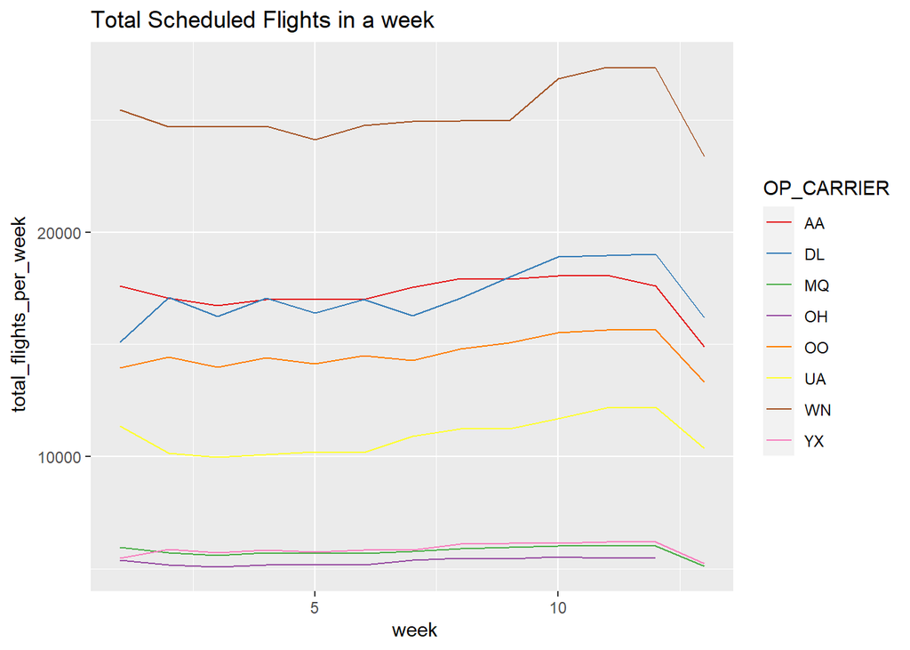

```r
flights_US_line_chart <- flights_US %>%
mutate(week =week(FL_DATE)) %>%
group_by(OP_CARRIER,week) %>%
summarise(total_flights_per_week = n(),
          cancellation_rate = round(sum(CANCELLED == 1)/n(),2),
          avg_arrival_delay = round(mean(ARR_DELAY,na.rm=TRUE),2),
          avg_departure_delay = round(mean(DEP_DELAY,na.rm=TRUE),2),
          avg_distance = round(mean(DISTANCE,na.rm=TRUE),2),
          avg_occupancy_rate = round(mean(OCCUPANCY_RATE,na.rm = TRUE),2) ) %>%
          filter(total_flights_per_week >= 5000 & OP_CARRIER %in% airlines_filter$OP_CARRIER)
# Creating a function to display  various line charts for analysis

challenge_line_chart <- function(dataset,column_name_x,column_name_y,group_column,title) {

  column_name_x <- enquo(column_name_x)

  column_name_y <- enquo(column_name_y)

  group_column <- enquo(group_column)

ggplot(data = dataset, aes(x = !!column_name_x, y = !!column_name_y, group = !!group_column)) +
  ggtitle(title) +
  geom_line(aes(color = !!group_column)) +
  xlab(column_name_x) +
  ylab(column_name_y) +
  scale_color_brewer(palette="Set1")

}

challenge_line_chart(flights_US_line_chart,week,total_flights_per_week,OP_CARRIER,'Total Scheduled Flights in a week')
```

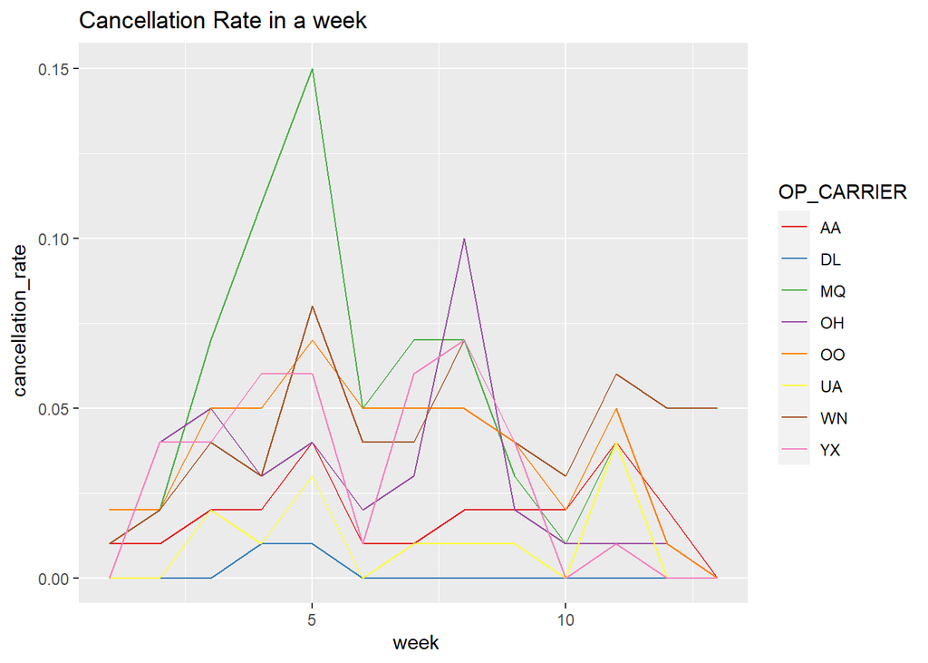

```r
challenge_line_chart(flights_US_line_chart,week,cancellation_rate,OP_CARRIER,'Cancellation Rate in a week')
```

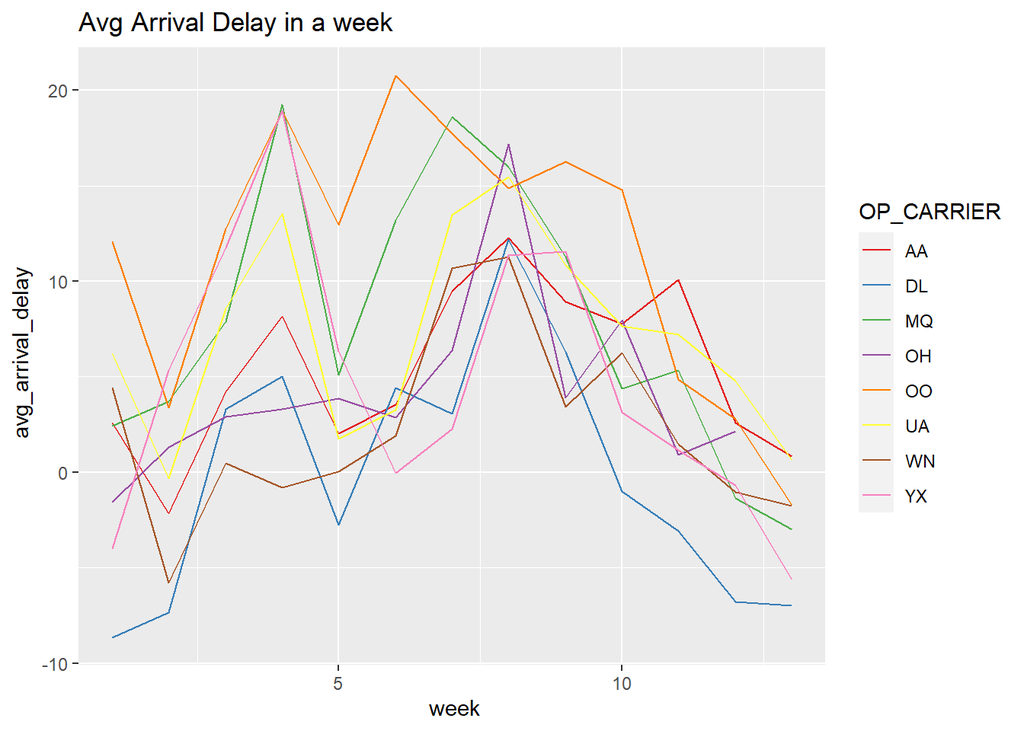

```r
challenge_line_chart(flights_US_line_chart,week,avg_arrival_delay,OP_CARRIER,'Avg Arrival Delay in a week')
```

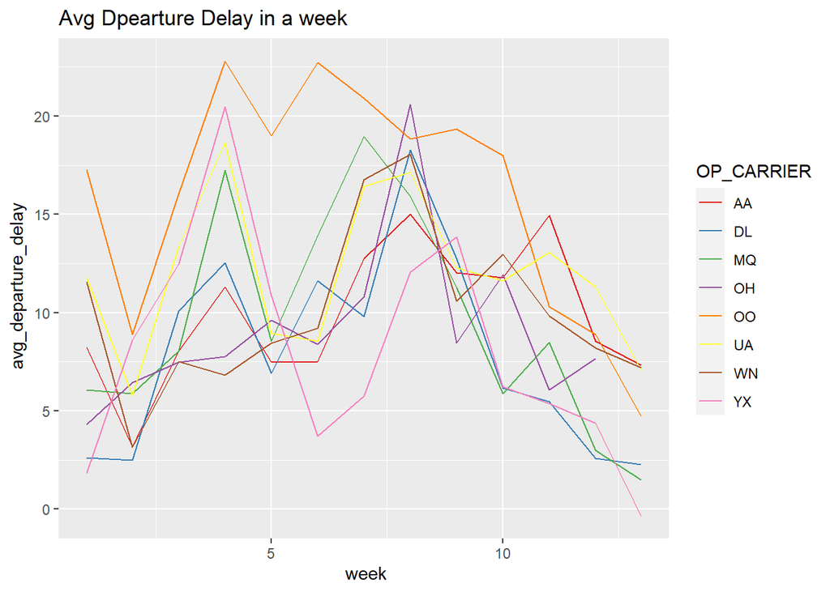

```r
challenge_line_chart(flights_US_line_chart,week,avg_departure_delay,OP_CARRIER,'Avg Dpearture Delay in a week')
```

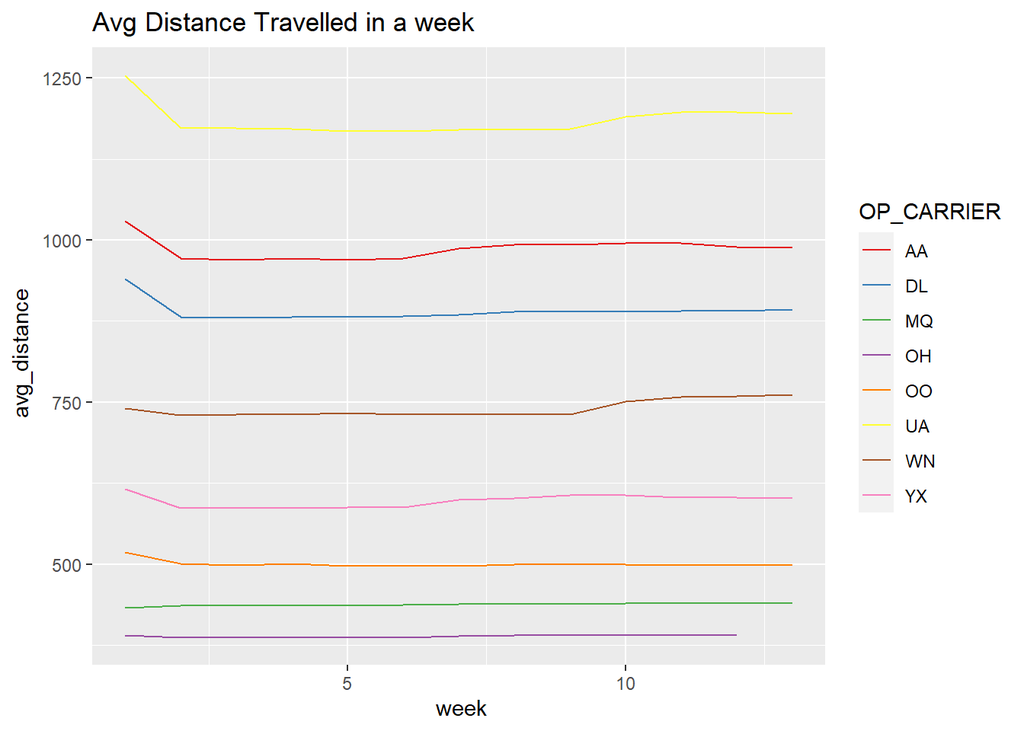

```r
challenge_line_chart(flights_US_line_chart,week,avg_distance,OP_CARRIER,'Avg Distance Travelled in a week')
```

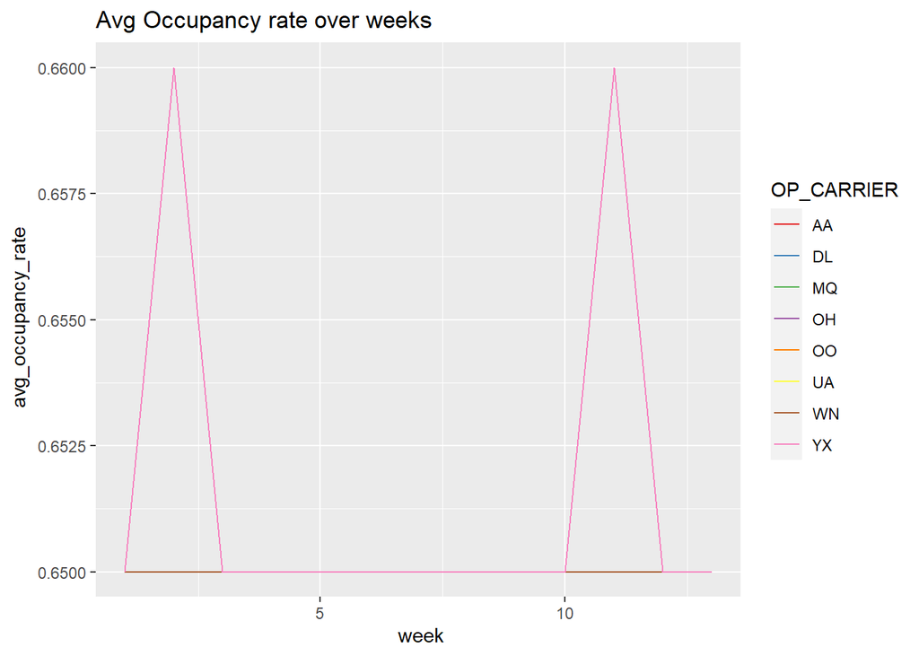

```r
challenge_line_chart(flights_US_line_chart,week,avg_occupancy_rate,OP_CARRIER,'Avg Occupancy rate over weeks')
```

```r
# creating a summarized variable to measure the percentage of occupancy rate greater than or equal to 75% for a origin-destination pair

flights_US_Origin_Desitination_Pairs <- flights_US %>%
    filter(CANCELLED == 0) %>%
      group_by(ORIGIN,ORIGIN_CITY_NAME,DESTINATION,DEST_CITY_NAME) %>%
        summarise(avg_arr_delay = round(mean(ARR_DELAY,na.rm=TRUE),2),
                  avg_dep_delay = round(mean(DEP_DELAY,na.rm=TRUE),2),
                  avg_distance = round(mean(DISTANCE,na.rm=TRUE),2),
                  avg_occupancy_rate = round(mean(OCCUPANCY_RATE,na.rm = TRUE),2),
                  high_occupancy_percentage = round(sum(OCCUPANCY_RATE>=0.75,na.rm=TRUE)/n(),2),
                  number_of_flights = n()
                  )
```

[output not shown]

```r
# joining with aggregated airport_codes to get name and type of aiport of origin and destination


flights_US_Origin_Desitination_Pairs <- inner_join(flights_US_Origin_Desitination_Pairs,airport_codes_US, by= c('ORIGIN'='IATA_CODE'))

flights_US_Origin_Desitination_Pairs <- inner_join(flights_US_Origin_Desitination_Pairs,airport_codes_US, by= c('DESTINATION'='IATA_CODE'))

flights_US_Origin_Desitination_Pairs <- flights_US_Origin_Desitination_Pairs %>% rename(origin_type = TYPE.x , destination_type = TYPE.y,
                                                                                        origin_name= NAME.x ,  destination_name = NAME.y)

# Getting unique origin-destination pairs and joining them with the data in the duplicates where destination is the origin and vice-versa

flights_US_Origin_Desitination_Pairs_unique <- flights_US_Origin_Desitination_Pairs[!duplicated(t(apply(flights_US_Origin_Desitination_Pairs[,c('ORIGIN','DESTINATION')], 1, sort))), ]


flights_US_Origin_Desitination_Pairs_dropped <- flights_US_Origin_Desitination_Pairs[duplicated(t(apply(flights_US_Origin_Desitination_Pairs[,c('ORIGIN','DESTINATION')], 1, sort))), ]

assessing_assumptions <- left_join(flights_US_Origin_Desitination_Pairs_dropped[,c('ORIGIN','DESTINATION','avg_arr_delay','avg_dep_delay','avg_distance','avg_occupancy_rate','number_of_flights')],flights_US_Origin_Desitination_Pairs_unique[,c('ORIGIN','DESTINATION','avg_arr_delay','avg_dep_delay','avg_distance','avg_occupancy_rate','number_of_flights')],by = c('ORIGIN'='DESTINATION','DESTINATION'='ORIGIN'))

# Ideally in a round trip,  arrival and departure delays are different for different airports and avg distance should be the same.
# Also, there is a possibility of different occupancy rate for two legs of the round trip
# Checking to see these assumptions are correct


assessing_assumptions %>%
  ungroup() %>%
    filter(avg_arr_delay.x != 0 & avg_dep_delay.x != 0 & avg_distance.x !=0 & avg_occupancy_rate.x != 0 & number_of_flights.x != 0) %>%
  summarise(
    mean_diff_avg_arr_delay = round(mean((avg_arr_delay.x-avg_arr_delay.y)/avg_arr_delay.x),2)*100,
    mean_diff_avg_dep_delay = round(mean((avg_dep_delay.x-avg_dep_delay.y)/avg_dep_delay.x),2)*100,
    mean_diff_avg_distance = round(mean((avg_distance.x-avg_distance.y)/avg_distance.x),2)*100,
    mean_diff_avg_occupancy_rate = round(mean(avg_occupancy_rate.x-avg_occupancy_rate.y),2)*100,
    mean_diff_number_of_flights = round(mean((number_of_flights.x-number_of_flights.y)/number_of_flights.x),2)*100
        )
```

```
## # A tibble: 1 × 5
##   mean_diff_avg_arr_delay mean_diff_avg_dep_delay mean_diff_av…¹ mean_…² mean_…³
##                     <dbl>                   <dbl>          <dbl>   <dbl>   <dbl>
## 1                     -25                       2              0       0       0
## # … with abbreviated variable names ¹mean_diff_avg_distance,
## #   ²mean_diff_avg_occupancy_rate, ³mean_diff_number_of_flights
```

```r
# As suspected, the arrival and departure delays are different. Also, the occupancy rates for both legs are same. So creating separate columns for just arrival and departure delays for origin and destination

flights_US_Origin_Desitination_Pairs_final <- left_join(flights_US_Origin_Desitination_Pairs_unique,flights_US_Origin_Desitination_Pairs_dropped[,c('ORIGIN','DESTINATION','avg_arr_delay','avg_dep_delay')],by=c('ORIGIN'='DESTINATION','DESTINATION'='ORIGIN'))


# If there is no data on the joined record we are replacing it with 0

flights_US_Origin_Desitination_Pairs_final <-
  flights_US_Origin_Desitination_Pairs_final %>%
    rename(avg_arr_delay_origin = avg_arr_delay.x,avg_dep_delay_origin = avg_dep_delay.x ,avg_arr_delay_destination = avg_arr_delay.y,avg_dep_delay_destination = avg_dep_delay.y) %>%
      mutate(
             avg_arr_delay_origin = ifelse(is.na(avg_arr_delay_origin),0,avg_arr_delay_origin),
             avg_dep_delay_origin = ifelse(is.na(avg_dep_delay_origin),0,avg_dep_delay_origin),
             avg_arr_delay_destination = ifelse(is.na(avg_arr_delay_destination),0,avg_arr_delay_destination),
             avg_dep_delay_destination = ifelse(is.na(avg_dep_delay_destination),0,avg_dep_delay_destination))
```

## Analyzing tickets data and joining it with flights data

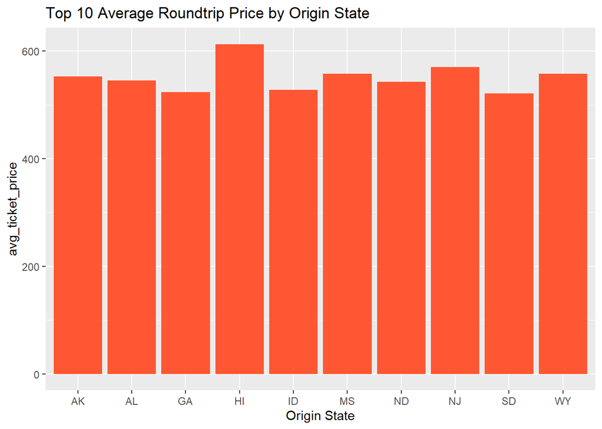

```r
tickets_US %>%
  filter(ROUNDTRIP==1) %>%
  group_by(ORIGIN_STATE_ABR) %>%
  summarise(avg_ticket_price=round(mean(ITIN_FARE,na.rm = TRUE)),2) %>%
  arrange(desc(avg_ticket_price)) %>%
  head(10 ) %>%
  ggplot(aes(x=ORIGIN_STATE_ABR,y=avg_ticket_price))+
  geom_bar(stat = "identity", fill = "#FF5733") +
      xlab("Origin State") +
        ggtitle('Top 10 Average Roundtrip Price by Origin State')
```

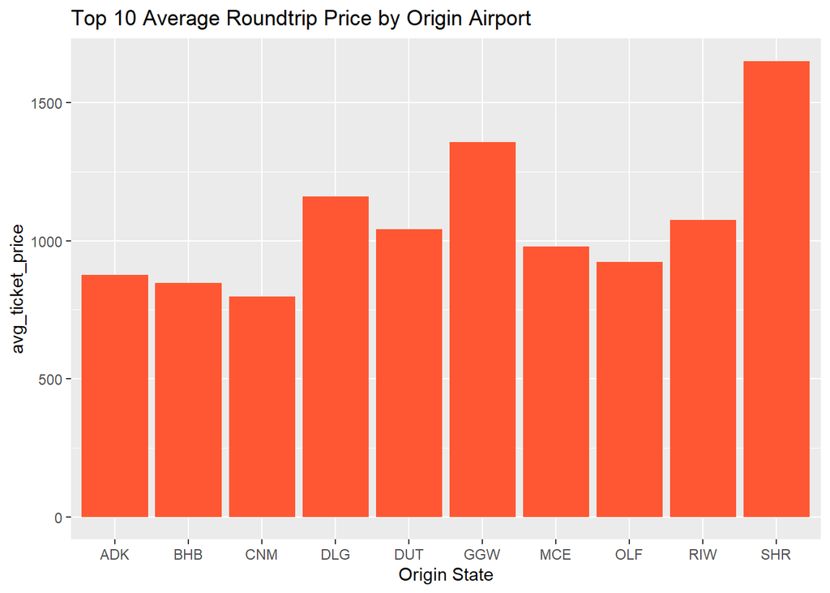

```r
tickets_US %>%
  filter(ROUNDTRIP==1) %>%
  group_by(ORIGIN) %>%
  summarise(avg_ticket_price=round(mean(ITIN_FARE,na.rm = TRUE)),2) %>%
  arrange(desc(avg_ticket_price)) %>%
  head(10 ) %>%
  ggplot(aes(x=ORIGIN,y=avg_ticket_price, na.rm = TRUE))+
  geom_bar(stat = "identity", fill = "#FF5733") +
      xlab("Origin State") +
        ggtitle('Top 10 Average Roundtrip Price by Origin Airport')
```

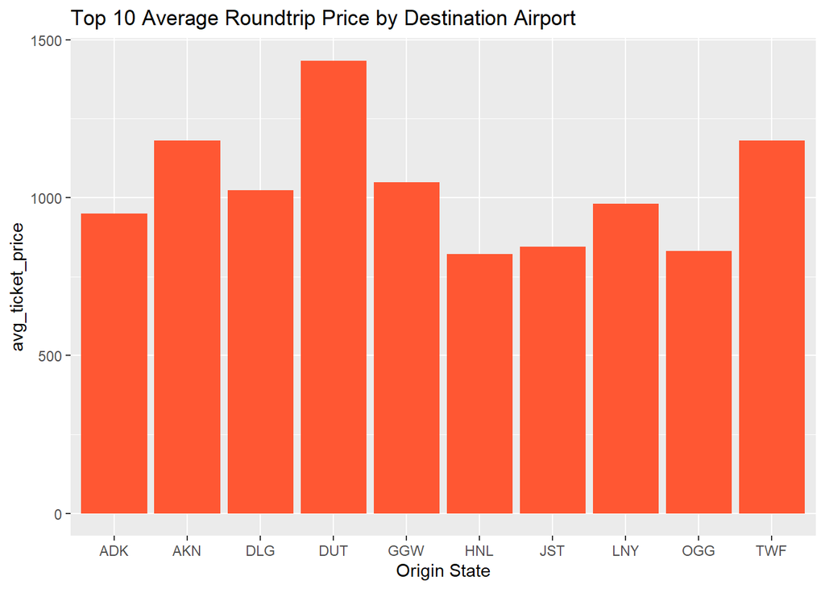

```r
tickets_US %>%
  filter(ROUNDTRIP==1) %>%
  group_by(DESTINATION) %>%
  summarise(avg_ticket_price=round(mean(ITIN_FARE, na.rm = TRUE)),2) %>%
  arrange(desc(avg_ticket_price)) %>%
  head(10 ) %>%
  ggplot(aes(x=DESTINATION,y=avg_ticket_price))+
  geom_bar(stat = "identity", fill = "#FF5733") +
      xlab("Origin State") +
        ggtitle('Top 10 Average Roundtrip Price by Destination Airport')
```

```r
tickets_US %>%
  filter(ROUNDTRIP==1) %>%
  group_by(REPORTING_CARRIER) %>%
  summarise(avg_ticket_price=round(mean(ITIN_FARE, na.rm = TRUE)),2) %>%
  arrange(desc(avg_ticket_price))
```

```
## # A tibble: 21 × 3
##    REPORTING_CARRIER avg_ticket_price   `2`
##    <chr>                        <dbl> <dbl>
##  1 HA                             607     2
##  2 UA                             579     2
##  3 DL                             557     2
##  4 OO                             516     2
##  5 YV                             511     2
##  6 AA                             509     2
##  7 MQ                             504     2
##  8 EV                             501     2
##  9 G7                             500     2
## 10 9E                             497     2
## # … with 11 more rows
```

```r
tickets_US_Origin_Destination_Pairs <- tickets_US %>%
    filter(ROUNDTRIP == 1) %>%
      group_by(ORIGIN,DESTINATION) %>%
        summarise(avg_round_trip_cost = round(mean(ITIN_FARE,na.rm = TRUE),2))
```

Findings

1.Round trips from Hawaii (HI) have the highest average round trip prices at ~$600. Incidentally, Hawaiian Airlines also has the highest average round trip ticket price at $607 2.SHR is the costliest airport to fly from with an average round trip ticket price of ~$1600 3. DUT is the costliest airport to fly into with an average round trip ticket price of ~$1400

## Creating the final data set by joining flights with airport type and tickets data

```r
dataset_final <- left_join(flights_US_Origin_Desitination_Pairs_final, tickets_US_Origin_Destination_Pairs, by = c("ORIGIN" = "ORIGIN", "DESTINATION" = "DESTINATION"))
```

# Checking final dataset for irregularities- Outliers, Imputing missing values

```r
summary(dataset_final)
```

```
##     ORIGIN          ORIGIN_CITY_NAME   DESTINATION        DEST_CITY_NAME
##  Length:2828        Length:2828        Length:2828        Length:2828
##  Class :character   Class :character   Class :character   Class :character
##  Mode  :character   Mode  :character   Mode  :character   Mode  :character
##
##
##
##
##  avg_arr_delay_origin avg_dep_delay_origin  avg_distance    avg_occupancy_rate
##  Min.   :-42.5000     Min.   :-14.500      Min.   :  31.0   Min.   :0.3800
##  1st Qu.: -0.5925     1st Qu.:  5.268      1st Qu.: 433.0   1st Qu.:0.6400
##  Median :  4.1000     Median :  9.395      Median : 737.5   Median :0.6500
##  Mean   :  5.8577     Mean   : 11.228      Mean   : 887.2   Mean   :0.6512
##  3rd Qu.: 10.2700     3rd Qu.: 14.825      3rd Qu.:1131.5   3rd Qu.:0.6600
##  Max.   :216.0000     Max.   :217.000      Max.   :9898.0   Max.   :0.9700
##
##  high_occupancy_percentage number_of_flights origin_name
##  Min.   :0.0000            Min.   :   1.0    Length:2828
##  1st Qu.:0.3400            1st Qu.:  88.0    Class :character
##  Median :0.3600            Median : 221.5    Mode  :character
##  Mean   :0.3656            Mean   : 324.3
##  3rd Qu.:0.3900            3rd Qu.: 419.0
##  Max.   :1.0000            Max.   :4164.0
##
##  origin_type        destination_name   destination_type
##  Length:2828        Length:2828        Length:2828
##  Class :character   Class :character   Class :character
##  Mode  :character   Mode  :character   Mode  :character
##
##
##
##
##  avg_arr_delay_destination avg_dep_delay_destination avg_round_trip_cost
##  Min.   :-41.000           Min.   :-13.340           Min.   :   0.0
##  1st Qu.: -1.200           1st Qu.:  4.758           1st Qu.: 339.7
##  Median :  3.535           Median :  8.950           Median : 419.2
##  Mean   :  4.978           Mean   : 10.371           Mean   : 430.3
##  3rd Qu.:  9.740           3rd Qu.: 14.248           3rd Qu.: 505.5
##  Max.   :200.000           Max.   :218.000           Max.   :9794.8
##                                                      NA's   :59
```

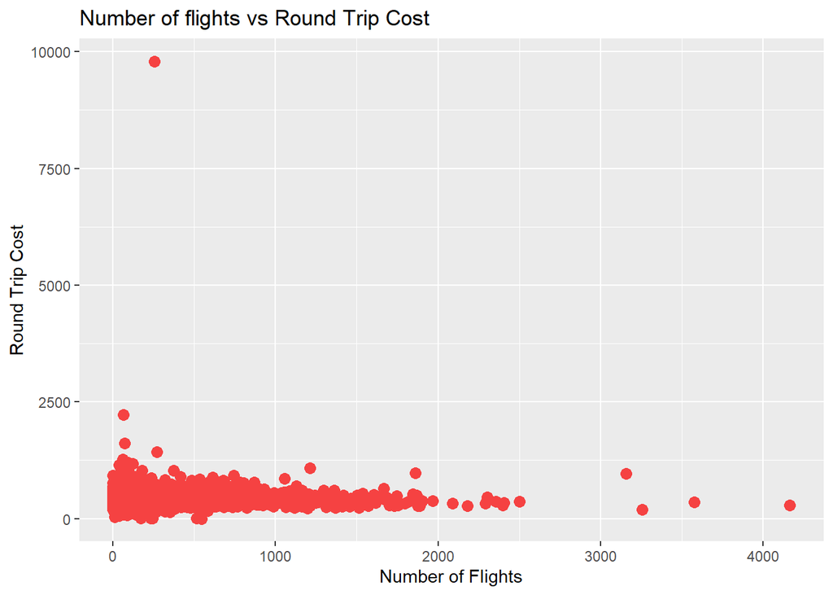

```r
# round_trip cost has 59 NA's

# To impute for missing values lets check relationship between roundtrip cost with number of flights and distance

dataset_final %>%
  ggplot(aes(number_of_flights,avg_round_trip_cost)) +
  geom_point(color = "#f54242",size= 3) +
  labs(title="Number of flights vs Round Trip Cost", x="Number of Flights", y="Round Trip Cost")
```

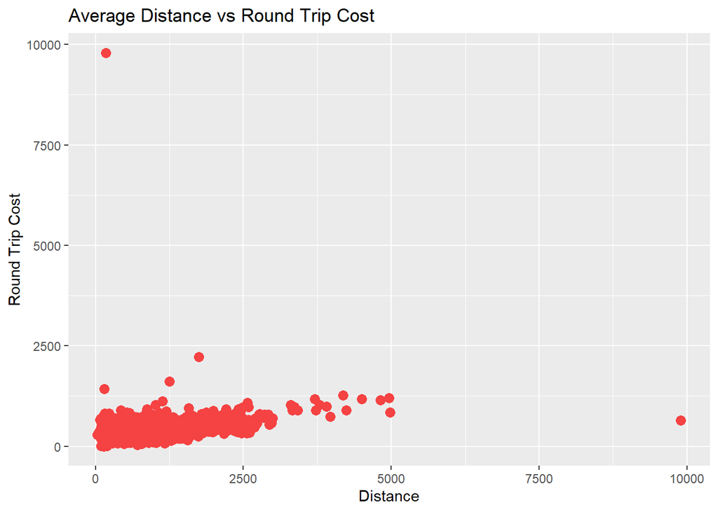

```r
dataset_final %>%
  ggplot(aes(avg_distance,avg_round_trip_cost)) +
  geom_point(color = "#f54242",size= 3) +
  labs(title="Average Distance vs Round Trip Cost", x="Distance", y="Round Trip Cost")
```